# Getting Started with LIVEtools

# Getting Started

## Introduction

R based programs to analyze and visualize embryo lineage after the cell data are extracted from 3D movies in Acetree Intended to process data tables where:

- each table represents one embryo
- each row represents one cell at a specific time point, with columns:
  - `time`: imaging time this cell read is created
  - `cell`: cell name
  - `x`: x position
  - `y`
  - `z`
  - `blot`: reporter expression

`LineageProcessing.R` contains functions to process one single embryo entity, and slices from embryo entities, which are the dependencies of other codes `CD_Processing.R` contains functions to work with a directory of several embryo data tables. Including functions to load data tables, retrieve specific cells and lineages data from multiple embryos, and operations that are only possible with multiple embryos (e.g. depth correction) `drawEmb.R` contains functions that plot all nuclei in an embryo in 3D

## Before you start

Before running the examples below, please ensure that you have installed [LIVEtools](https://github.com/johnmurraylab/LIVE_tools#installation) and its dependencies.

```r
library("LIVEtools")
```

## Working with Single Embryos

### Loading a Single Embryo

```r
# Load a single embryo file (from StarryNite format zip file)
# Genotype: JIM767 is tbx-35(tm1789) II; pha-4::GFP; ...
embryo_list <- readEmbryoTable(file = "sample_data/20241108_JIM767_25_L5-edit.zip")
```

**IMPORTANT: Extract the data.frame from the returned list using [[1]]**

The list contains: `[[1]]` = data.frame, `[[2]]` = boolean for time correction

```r
embryo <- embryo_list[[1]]
# Verify we have a data.frame
if(is.data.frame(embryo)){print(dim(embryo))} #should have many rows
```

```
[1] 74017    11
```

### Selecting Cells and Timepoints

The `grepCells()` function is a powerful tool for extracting specific cells from your embryo data. It’s used internally by plotting and analysis functions, but you can also use it directly to inspect your data. We will work through its features in this section.

If you are in RStudio, you can open the extracted data.frame’s from the **Environment** menu (the table icon on the right) and view what actual observations are retrieved.

#### Select Specific Cells or Lineages

```r
# Get all cells at time=100
cells_t100 <- grepCells(
  embryo,
  lineages = "ALL", # putting "ALL" into either lineages or cells argument retrieves all cells
  times = 100) # the default of times is an "ALL" so don't have to modify times if not time-selective

# Get specific cells by exact names
cells_specific <- grepCells(embryo,
                            cells = c("ABalp", "ABara"),
                            times = 20)

# Get entire lineage (a cell and all its descendants)
cells_lineage <- grepCells(embryo,
                           lineages = "ABal",  # ABal and all daughters
                           times = 100)        # at time 100

# Mix specific cells and lineages
cells_mixed <- grepCells(embryo,
                         cells = c("MSaaapp", "Epla"), # Just these two cells
                         lineages = "ABal",            # Plus the entire ABal lineage
                         times = 100)

# P1, P2, P3, P4 as lineages arguments represents themselves and all their descendants
cells_P2 <- grepCells(embryo,
                      lineages = "P2",
                      times = 100)
```

#### Using Wildcards

`"x"` is a single-letter wildcard that works the same as “x” in *C. elegans* cell naming convention:

```r
# Get all left-right sister pairs in the ABa lineage
cells_wildcard <- grepCells(embryo,
                            cells = c("MSaxaa", "Exla"),  # Matches MSaaaa/MSapaa, Eala/Epla
                            times = 100)

# 4th generation E cells (left/right variants)
cells_E4 <- grepCells(embryo,
                      cells = "Eaxx",  # 4th generation E cells that are descendants of Ea
                      times = 100)

lineages_Msxa <- grepCells(embryo,
                           lineages = "MSxa", #every descendant of MSaa/MSpa
                           times = 100)
```

#### Time Matching Behavior

If no exact time match is found, `grepCells()` finds the nearest time point within a threshold:

```r
# Request time=100.33 (doesn't exist)
cells_nearest <- grepCells(embryo, lineages = "ALL", times = 100.33)
# Will return cells from nearest time (e.g., time=100 or time=101)

# Check what time was actually matched
cat("matched time:", unique(cells_nearest$time))
```

```
matched time: 100
```

```r
# Multiple timepoints
cells_multi <- grepCells(embryo, lineages = "E", times = c(80, 100, 120))
```

#### Inspect the Data

View the structure of extracted data:

```r
# See what columns are available
names(cells_t100)
```

```
 [1] "x"       "y"       "z"       "size"    "cell"    "time"    "gweight" "cross"   "global"  "local"   "blot"
```

```r
# Summary statistics
summary(cells_t100$blot)  # Expression values
```

```
   Min. 1st Qu.  Median    Mean 3rd Qu.    Max.
 -590.0  -253.0  -140.0   335.4     6.0  7103.0
```

```r
# Find specific cells in your selection
cells_t100[cells_t100$cell == "MSaaapa", ]
```

```
       x   y  z size    cell time gweight cross global local blot
6830 486 290 35   38 MSaaapa  100  213592   990  25000    39   24
```

**Note:** This flexible selection logic (wildcards, lineages, time matching) is also used by: - 3D plotting: `drawEmbLine()`, `drawEmbVal()` - Positioning: `RePosition()`, `totalRePosition()` - Expression plotting: `plotBlotLine()` (for multi-embryo data)

### Visualizing Single Embryo in 3D

#### Basic 3D Lineage Plot

Plot nucleus positions in 3D space. Without specifying lineages, the function groups cells into the default 7 lineages: ABa, ABp, MS, E, C, D, P4.

```r
figO <- drawEmbLine(
  embryo, time=139, cellSize=10, title = "Default 7 Lineages",
  xSize=0.08651, ySize=0.08651, zSize=0.5 # Specify coordinate scales for raw data
  )
```

```
automatically assigning "alphas"
```

```
automatically assigning `colors`
```

```r
figO[[1]]
```

[interactive chart not shown]

#### Align Embryo Position and Orientation

`totalRePosition()` centers the embryo at (0,0,0) and aligns it to standard axes: - Posterior → x+ direction - Right → y+ direction - Dorsal → z+ direction

```r
rotatedEmbryo <- totalRePosition(
  embryo, time = 139,
  indicatorP = "C",      # Posterior marker
  indicatorD = "Cxa",    # Dorsal marker
  indicatorV = "MSxxp",  # Ventral marker
  xSize=0.08651, ySize=0.08651, zSize=0.5) # After rotation, coordinate scales are normalized (xSize=ySize=zSize=1)
figRotated <- drawEmbLine(
  rotatedEmbryo, time = 139, title = "Default Lineages Aligned", cellSize=10
  )
```

```
automatically assigning "alphas"
```

```
automatically assigning `colors`
```

```r
figRotated[[1]]
```

[interactive chart not shown]

#### Customize Lineage Display

Highlight specific lineages with custom colors and transparency: `drawEmbLine` function allows user to select an array of lineages to highlight, then assign color and alpha (transparency) for **each selected lineage** as two array with corresponding ordering. Uses the same cell/lineage selection logic as `grepCells()` (see “Selecting Cells and Timepoints” section).

- Nucleus not selected will be grey and transparent.
- The colors and alphas should be delivered as lists where each element correspond to one lineage in “lineges” list.
- If no colors are indicated, or the length of colors array doesn’t match that of lineages list, the function will automatically assign unique colors from viridis palette.

```r
figABp <- drawEmbLine(
  rotatedEmbryo,
  lineages = c("ABxlx", "C"),
  colors = c(rgb(0.7,0,0.5),rgb(0.3,1,0)), #"ABp" will have rgb(0.7,0,0.5),
  alphas = c(0.3, 1),
  cellSize=6, time = 139
  )
figABp[[1]]
```

[interactive chart not shown]

#### Plot Gene Expression in 3D

Color cells by reporter expression levels:

```r
# Default Viridis color scale
figVal <- drawEmbVal(
  rotatedEmbryo, time = 139, title = "expression in default color scale",
  cellSize=10)
figVal[[1]]
```

[interactive chart not shown]

#### Custom Color Scale for Expression

`drawEmbVal` function offers several options to customize colors through `colorScheme` argument

```r
figVal <- drawEmbVal(
  rotatedEmbryo, time = 139, title = "Expression - Custom Colors",
  colorScheme = list( # Map normalized values (0=min, 1=max) to colors
    c(0,rgb(0,0,0)),    # Black at minimum
    c(1/3,rgb(0,0,1)),  # Blue at 1/3
    c(2/3,rgb(1,1,1)),  # White at 2/3
    c(1,rgb(1,0,0))     # Red at maximum
  ),
)
figVal[[1]]
```

[interactive chart not shown]

Alternatively, use named color scales: Blackbody, Bluered, Blues, Cividis, Earth, Electric, Greens, Greys, Hot, Jet, Picnic, Portland, Rainbow, RdBu, Reds, Viridis, YlGnBu, YlOrRd.

#### Lineage Tree colored by Expression

```r
treeplot <- CD_tree_plot(
  rotatedEmbryo,
  root = "ABara",         # Starting cell
  end_time=139,           # Only show lineage up to this time
  min_gain=-1000,         # Color scale minimum
  max_gain = 8000,        # Color scale maximum
  transform = "identity"  # "identity" for linear color scale. "log2", "log10", or "log" for better resolution at low expression
)
```

```
ADDING PARENTS FOR:4CELLS
```

```
ABa ABp EMS P2
```

```
ADDING PARENTS FOR:2CELLS
```

```
AB P1
```

```
1 cells don't have sisters - should equal one for P0
```

```
adjusting max gain
```

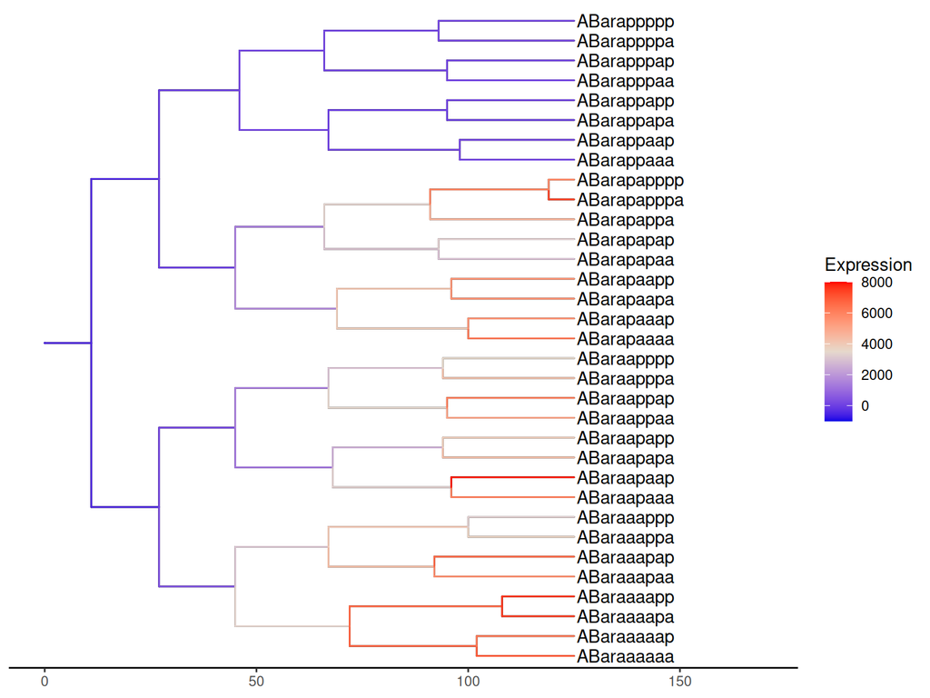

```r
treeplot
```

### Saving a Single Embryo

After processing (e.g., rotation, manual corrections), save your modified embryo with R built-in `write.csv`:

```r
#prepare a directory
dir_path <- "output_single"
if(!dir.exists(dir_path)){dir.create(dir_path, recursive = TRUE, showWarnings = FALSE)}
```

#### Save Cell Tracking Data Only

```r
write.csv(
  rotatedEmbryo,
  file = "output_single/CDembryo1_rotated.csv",
  row.names = FALSE  # Important: prevents adding row numbers as a column
)
```

#### Save with Metadata

If you have metadata to preserve:

```r
# Create or update metadata
embryo_info <- data.frame(
  name = "embryo1",
  rotated = TRUE,
  depth_corrected = FALSE,
  time_corrected = FALSE
)

# Save both files
write.csv(rotatedEmbryo, "output_single/CDembryo1_rotated.csv", row.names = FALSE)
write.csv(embryo_info, "output_single/embryo1Info.csv", row.names = FALSE)
```

#### Reload a Saved Embryo

```r
# Read.csv returns a data.frame directly (no [[1]] needed)
embryo_reloaded <- read.csv("output_single/CDembryo1_rotated.csv", header = TRUE)
embryo_info_reloaded <- read.csv("output_single/embryo1Info.csv", header = TRUE)

# Verify
dim(embryo_reloaded)
```

```
[1] 74017    11
```

```r
head(embryo_reloaded)
```

```
           x          y          z size cell time gweight cross global local blot
1 -16.950468 -2.4662480 -3.4289286   90  ABa    1 2605113   408  25000  -823 -823
2   6.900302 -4.4903201 -1.1585847   78  EMS    1 1450294   546  25000  -628 -628
3  23.161345 -0.6798298  1.0258777   78   P2    1 1908969   487  25000  -772 -772
4   2.193654 10.2991132  2.1777642   90  ABp    1 2845506   469  25000  -731 -731
5 -16.460531 -0.9105992  0.2128567   90  ABa    2 3154039   471  25000  -798 -798
6   2.596404  9.1665799  4.5023888   82  ABp    2 2635634   473  25000  -658 -658
```

```r
embryo_info_reloaded$rotated  # Check processing status
```

```
[1] TRUE
```

**Important considerations:** - Always use `row.names = FALSE` when saving to avoid adding an extra index column - Use consistent naming conventions (e.g., “CD” prefix for cell data, “AuxInfo” suffix for metadata) - The standard `read.csv()` with `header = TRUE` is sufficient for reloading - Unlike `readEmbryoTable()`, `read.csv()` returns a data.frame directly (not a list)

## Process a Batch of Embryos

### Loading Multiple Embryos

#### Input Directory Structure

When processing multiple embryos with `CD_In()`, the input directory should contain:

```
data_directory/
  ├── CDembryo1.csv       # Cell tracking data table for embryo 1
  ├── CDembryo2.csv       # Cell tracking data table for embryo 2
  ├── ...
  ├── TIMEembryo1.csv     # (Optional) Actual imaging times for time correction
  ├── TIMEembryo2.csv
  ├── ...
  ├── embryo1AuxInfo.csv  # (Optional) Metadata: coordinate scales, rotation status, etc.
  ├── embryo2AuxInfo.csv
  └── ...
```

#### Read a directory of embryo tables

```r
embryos <- CD_In(directory = "sample_data/JIM767_25/", prefix = "CD",
                 time.prefix = "TIME", time.suffix = ".csv",
                 info.prefix = "", info.suffix = "AuxInfo.csv")
```

```
getting time data from: sample_data/JIM767_25/TIME20241009_JIM767_25_L1.csv
```

```
getting time data from: sample_data/JIM767_25/TIME20241009_JIM767_25_L5.csv
```

```
getting time data from: sample_data/JIM767_25/TIME20241010_JIM767_25_L2.csv
```

```
getting time data from: sample_data/JIM767_25/TIME20241010_JIM767_25_L3.csv
```

```
getting time data from: sample_data/JIM767_25/TIME20241107_JIM767_25_L1.csv
```

```
getting time data from: sample_data/JIM767_25/TIME20241107_JIM767_25_L3.csv
```

```
getting time data from: sample_data/JIM767_25/TIME20241108_JIM767_25_L4.csv
```

```
getting time data from: sample_data/JIM767_25/TIME20241108_JIM767_25_L5.csv
```

```
getting time data from: sample_data/JIM767_25/TIME20250419_JIM767_pha4GFP_25_L4.csv
```

#### Understanding the Returned Structure

`CD_In()` returns a nested list:

```
embryos                   # Main list object
  ├── $CD                 # List of cell tracking data.frames
  │   ├── $embryo1        # data.frame from CDembryo1.csv
  │   ├── $embryo2        # data.frame from CDembryo2.csv
  │   └── ...
  └── $info               # List of metadata data.frames
      ├── $embryo1        # data.frame from embryo1Info.csv + auto-generated flags
      ├── $embryo2        # data.frame from embryo2Info.csv + auto-generated flags
      └── ...
```

The `$info` data.frames track processing status: - `name`: Embryo identifier - `depth_corrected`: TRUE if depth correction was applied - `time_corrected`: TRUE if TIME files were used - `rotated`: TRUE if rotation was applied - Plus any custom fields from your Info files

### Accessing Individual Embryos

**Method 1: By index (quick but loses identity)**

```r
exEmbryo <- embryos[["CD"]][[1]]
# WARNING: You won't know which embryo this is!
```

**Method 2: With metadata (recommended)**

```r
exEmbryo <- embryos[["CD"]][[1]]
exEmbryo_info <- embryos[["info"]][[1]]

embryo_name <- exEmbryo_info$name  # Now you can identify it
```

**Method 3: By name (best practice)**

```r
embryo_name <- "embryo1"
exEmbryo <- embryos[["CD"]][[embryo_name]]
exEmbryo_info <- embryos[["info"]][[embryo_name]]
```

### Working with Multi-Embryo Data

Many functions in this package are designed to work with the entire `embryos` list structure. For example, `plotBlotLine()` automatically processes all embryos and plots them together. However, 3D visualization and tree plotting functions (`drawEmbLine()`, `drawEmbVal()`, `CD_tree_plot()`) require a **single embryo data.frame** as input.

**Iterate over all embryos:**

```r
embryo_names <- names(embryos[["CD"]])

for (emb_name in embryo_names) {
  this_embryo <- embryos[["CD"]][[emb_name]]
  this_info <- embryos[["info"]][[emb_name]]

  # Process each embryo (e.g., create plots with embryo-specific filenames)
}
```

### Selecting Cells Across Multiple Embryos

The `getCells()` function extracts specific cells from all embryos in your dataset. It works like `grepCells()` but operates on the entire multi-embryo structure.

Like `grepCells()`, `getCells()` supports wildcards and mixing cells/lineages:

```r
# Mix specific cells and lineages with wildcards
mixed_cells <- getCells(embryos,
                        cells = c("MSaxaa", "Exla"),     # Wildcards
                        lineages = c("ABal", "ABpr"),   # Full lineages
                        times = 100)

# Inspect results from first embryo
head(mixed_cells[[1]])
```

```
     time       cellTime       cell none global local blot cross  z   x   y size gweight
8597  100       Eala:100       Eala 2481 -22519  1289 1282  2481 47 442 362   46  209722
8692  100       Epla:100       Epla 1943 -23057  1075 1070  1943 50 362 520   50  235179
8554  100 ABalpapppa:100 ABalpapppa 5178 -19822  2709 2888  5178 31 460 302   30  114400
8555  100 ABalpaappp:100 ABalpaappp 2374 -22626   924  927  2374 34 546 298   30  175229
8557  100 ABalpappap:100 ABalpappap 3001 -21999  1161 1226  3001 24 472 308   34  118474
8564  100  ABalpppaa:100  ABalpppaa  603 -24397    10    1   603 43 620 306   38  447908
```

### Multi-Embryo Analysis

#### Depth Correction

Absorption and scattering of the excitation light and fluorescence cause to fluorescence intensity to decrease as image depth increase away from fluorescence source. We model the light attenuation effect with a logarithmic model: $f = f_{real} \times e^{a \times z} \times b$ where $a$ and $b$ are factors to be determined, and $z$ is the depth. We then assume that the same lineage have relatively constant expression levels and therefore comparable in terms of response to fluorescence strength. So in `depthCorrectionParm` function, we can select lineages to fit their fluoresence-vs-depth curve against the model. The output model can be applied to the embryos where the model was learned, or a different set of embryos in function `dataCorrection`.

```r
# get the correction parameters for the model of fluoresence loss by depth
model <- depthCorrectionParm(
  embryos,
  lineage = c("ABara", "ABalp", "E"),  # Cells used for fluoresence loss fitting
  alignCell = "E",                     # Cell used for alignment
  startT = 30, endT = 150,             # Time window for fitting
  exc_zMin = 0.2, exc_zMax = 1,        #excitation strength at z=1 and zMax
  zMax = 67)                           # Maximum z coordinate

# Apply Correction
embryos <- embryos |>
  dataCorrection(lineage=c("ABara", "ABalp", "P1"),
                 model = model,
                 zMax = 67, exc_zMin = 0.2, exc_zMax = 1)
```

#### Plot Expression Over Time

`plotBlotLine` function plot the expression of selected cells, averaged in each embryo at each time point. Each embryo will be represented by a unique curve.

- Uses `getCells()` internally for flexible cell selection (see “Selecting Cells Across Multiple Embryos” section).
- Synchronize start point for each embryo: if an `aligningCell` argument is delivered, the function will translate the time points in each embryo to make the last time point of `aligningCell` lifespan equal to `align_t` time.

```r
# Set up plot parameters
yrange = list(0,16000)
xrange = list(-50,150)
embNames <- names(embryos[["CD"]])

#set up consistent color palette for the same embryo across different plots
emb_palette <- viridis::viridis(length(embNames)) |> setNames(embNames)
# Define cells to track
cellsExp <- c("ABal", "ABalp", "ABalpa", "ABalpaa", "ABalpaaa", "ABalpaaaa", "ABalpaaaaa")

fig_blot_cells <- embryos|>plotBlotLine(
  title = 'specific cells example', color_palette = emb_palette,
  aligningCell = "ABal", align_t = 0, # Align this cell's end time to 0 in all embryos
  cells = cellsExp,
  xrange = xrange, yrange = yrange)
fig_blot_cells
```

[interactive chart not shown]

**Track Expression with Various Cell and Lineage Representations**

```r
fig_blot_lines <- embryos|>plotBlotLine(title = 'lineages example',
                            aligningCell = "ABalp", align_t = 0,
                            cells = c("Exxx", "Exxxx"), #every 4th and 5th generation E cell
                            lineages = c("ABalp","ABara"),
                            color_palette = emb_palette,
                            xrange = xrange, yrange = yrange)
fig_blot_lines
```

[interactive chart not shown]

### Saving Multiple Embryos

After processing your embryo data (e.g., depth correction, time alignment), you’ll want to save the modified data for future use. The `CD_Save()` function writes all embryos in your dataset back to CSV files.

**Basic usage:**

```r
#again, prepare a directory
dir_path_multi <- "output_multi"
if(!dir.exists(dir_path_multi)){dir.create(dir_path_multi, recursive = TRUE, showWarnings = FALSE)}
# Save all embryos to the "dir_path_multi" directory
CD_Save(CDDataL = embryos, saveDir = dir_path_multi)
```

**Resulting file structure:** After running `CD_Save()`, your output directory will contain:

```
output/
  ├── CDembryo1.csv       # Modified cell tracking data for embryo 1
  ├── CDembryo2.csv       # Modified cell tracking data for embryo 2
  ├── ...
  ├── embryo1Info.csv     # Updated metadata for embryo 1 (includes processing flags)
  ├── embryo2Info.csv     # Updated metadata for embryo 2
  └── ...
```

**Important notes:** - The function automatically adds a trailing “/” to `saveDir` if needed - CD files use prefix “CD” + original embryo name from `CD_In()` - Info files use embryo name + “Info.csv” suffix - Processing flags are automatically updated (depth_corrected, time_corrected, etc.) - Existing files with name collisions are **overwritten**

**Reloading saved data:**

```r
# Load your processed data in a future session
embryos_reloaded <- CD_In(
  directory = dir_path_multi,
  prefix = "CD",
  info.prefix = "",
  info.suffix = "Info.csv"
)

# Check processing status
embryos_reloaded[["info"]][[1]]$depth_corrected  # Should be TRUE
```

```
[1] TRUE
```

### 3D Visualization from Multi-Embryo Data

The 3D plotting functions (`drawEmbLine`, `drawEmbVal`) require a single embryo data.frame as input, not the full multi-embryo list.

#### Extract and Visualize One Embryo

```r
# Extract first embryo with its metadata
embryo_names <- names(embryos[["CD"]])
first_emb_name <- embryo_names[1]

exEmbryo <- embryos[["CD"]][[first_emb_name]]
exEmbryo_info <- embryos[["info"]][[first_emb_name]]

# Now we can identify this embryo
message("Processing embryo: ", exEmbryo_info$name)
```

```
Processing embryo: 20241009_JIM767_25_L1
```

```r
# Rotate and visualize
exEmbryoRotated <- totalRePosition(
  exEmbryo, time = 139, indicatorP = "C", indicatorD = "Cxa", indicatorV = "MSxxp",
  xSize=0.08651, ySize=0.08651, zSize=0.5)

fig_3D_list <- drawEmbLine(exEmbryoRotated, time=139, title=first_emb_name, cellSize = 5)
```

```
automatically assigning "alphas"
```

```
automatically assigning `colors`
```

```r
fig_3D_list[[1]]
```

[interactive chart not shown]

#### Save the 3D Plot as Static Images

The `saveEmbImg()` function requires Python dependencies (plotly, kaleido). Set up once:

```r
#setup reticulate dependencies
library(reticulate)
#point your python installation to reticulate
reticulate::use_virtualenv("../LIVEtools_venv/")
#reticulate wake-up call
reticulate::py_run_string("import sys")

outdir <- "output_img/"
dir.create(outdir, recursive = TRUE, showWarnings = FALSE)
```

**Save a single frame:**

```r
saveEmbImg(fig_3D_list[[1]], output_file="output_img/example_3D.png",keepLabels=TRUE)
```

#### Generate Image Sequences for Movies

Create a series of images across developmental time that could be combined make a movie (in FIJI or other image analysis software)

```r
for(time in 1:20){
    if(time %% 5 == 0){
        message("Processing time point ", time)
    }
    fig_3D_list <- drawEmbLine(
        exEmbryoRotated, time, cellSize=15,
        xSize=1, ySize=1, zSize=1 #unprocessed data can have different x,y,z scales, specify here
    )
    suppressMessages(
      saveEmbImg(
        fig_3D_list[[1]],
        output_file=paste0(outdir, "example_3D", time,".png"),
        keepLabels=TRUE,
        width = 800, height = 650, zoom=1.3)
    )
}
```

## Troubleshooting

**Problem: Error when using embryo_list directly in plotting**

- **Cause**: `readEmbryoTable()` returns a list, but plotting functions expect a data.frame
- **Solution**: Extract with `[[1]]`: `embryo <- embryo_list[[1]]`

**Problem: “Cannot open file for writing”**

- **Cause**: Output directory doesn’t exist or insufficient permissions
- **Solution**: `dir.create("output", recursive = TRUE, showWarnings = FALSE)`

**Problem: Reloaded data has extra “X” column**

- **Cause**: Saved with `row.names = TRUE` (the default)
- **Solution**: Always use `row.names = FALSE` in `write.csv()`

**Problem: Lost embryo identity after extraction**

- **Cause**: Extracted embryo without its metadata
- **Solution**: Extract both: `embryos[["CD"]][[name]]` and `embryos[["info"]][[name]]`

**Problem: Unable to reload with `CD_In()`**

- **Cause**: File naming doesn’t match prefix/suffix patterns
- **Solution**: Ensure files follow conventions:
  - Cell data: `[prefix][embryoName].csv` (e.g., `CDembryo1.csv`)
  - Metadata: `[info.prefix][embryoName][info.suffix]` (e.g., `embryo1Info.csv`)